# Binary Classification Exercise for Kreditech

Peter Martey Addo Lead Data Scientist, SNCF Mobilite

17 November 2017

[figure not shown]

Source: Google Images

# 1 Loading Packages, Reading and loading data

```r
suppressMessages(library(h2o))
#
### use when under sncf proxy ###
Sys.unsetenv("https_proxy")
Sys.unsetenv("http_proxy")
#h2o.removeAll() ## clean slate - just in case the cluster was already running
suppressMessages(h2o.init(nthreads = -1))
h2o.no_progress() # Don't show progress bars in RMarkdown output
```

## 1.1 Load data

We import the data and check the dimensions

```r
train <- h2o.importFile(path = normalizePath("./data/Training.csv"))
valid <- h2o.importFile(path = normalizePath("./data/Validation.csv"))
dim(train)
dim(valid)
```

[output not shown]

Let check the data structure and content

```r
h2o.str(train)
```

```
## Class 'H2OFrame' <environment: 0x7ff4ed330b58>
##  - attr(*, "op")= chr "Parse"
##  - attr(*, "id")= chr "Training.hex_sid_8fd6_1"
##  - attr(*, "eval")= logi FALSE
##  - attr(*, "nrow")= int 3700
##  - attr(*, "ncol")= int 22
##  - attr(*, "types")=List of 22
##   ..$ : chr "enum"
##   ..$ : chr "enum"
##   ..$ : chr "real"
##   ..$ : chr "enum"
##   ..$ : chr "real"
##   ..$ : chr "enum"
##   ..$ : chr "enum"
##   ..$ : chr "int"
##   ..$ : chr "real"
##   ..$ : chr "int"
##   ..$ : chr "enum"
##   ..$ : chr "real"
##   ..$ : chr "enum"
##   ..$ : chr "enum"
##   ..$ : chr "enum"
##   ..$ : chr "int"
##   ..$ : chr "int"
##   ..$ : chr "enum"
##   ..$ : chr "int"
##   ..$ : chr "enum"
##   ..$ : chr "enum"
##   ..$ : chr "enum"
##  - attr(*, "data")='data.frame': 10 obs. of  22 variables:
##   ..$ v33       : Factor w/ 10 levels "NA","bb","dd",..: 9 9 4 8 9 5 6 5 9 5
##   ..$ v76       : Factor w/ 3 levels "g","p","s": 1 3 1 1 1 1 1 1 1 1
##   ..$ v12       : num  17.9 16.9 31.2 48.2 32.3 ...
##   ..$ v68       : Factor w/ 2 levels "f","t": 1 1 1 1 2 1 2 1 1 1
##   ..$ v50       : num  1.75 0.29 0 0.335 0.5 ...
##   ..$ v7        : Factor w/ 3 levels "NA","a","b": 2 3 3 2 3 2 2 3 3 3
##   ..$ v70       : Factor w/ 2 levels "f","t": 2 1 2 1 1 1 1 1 1 1
##   ..$ v55       : num  80 200 96 0 232 160 276 280 220 320
##   ..$ v20       : num  5.40e-05 3.35e-05 1.12e-04 1.33e-04 3.50e-04 ...
##   ..$ v24       : num  1 0 1 0 0 0 0 0 0 0
##   ..$ v32       : Factor w/ 4 levels "NA","l","u","y": 3 4 3 3 3 4 3 4 3 3
##   ..$ v97       : num  2.82 3.45 3.24 4.21 3.44 3.64 2.74 4.03 2.49 2.96
##   ..$ v28       : Factor w/ 2 levels "f","t": 2 1 1 1 2 2 2 1 1 1
##   ..$ v99       : Factor w/ 15 levels "NA","W","aa",..: 4 11 8 9 11 9 10 4 4 4
##   ..$ v95       : Factor w/ 3 levels "NA","f","t": 3 1 3 1 2 2 1 1 1 1
##   ..$ v42       : num  800000 2000000 960000 0 2320000 1600000 2760000 2800000 2200000 3200000
##   ..$ v53       : num  5 0 19 120 0 0 1 204 140 13
##   ..$ v85       : Factor w/ 4 levels "NA","g","gg",..: 2 4 2 2 2 4 2 4 2 2
##   ..$ v9        : num  0 1 0 1 1 0 1 1 0 0
##   ..$ v84       : Factor w/ 2 levels "f","t": 1 1 1 1 1 1 1 1 1 1
##   ..$ v44       : Factor w/ 2 levels "f","t": 1 1 1 1 1 1 1 1 1 1
##   ..$ classlabel: Factor w/ 2 levels "no.","yes.": 1 1 1 1 1 1 1 1 1 1
```

```r
h2o.describe(train)
```

```
##         Label Type Missing Zeros PosInf NegInf   Min       Max
## 1         v33 enum       0    66      0      0  0.00 9.000e+00
## 2         v76 enum       0  3430      0      0  0.00 2.000e+00
## 3         v12 real      39     0      0      0 13.75 8.025e+01
## 4         v68 enum       0   277      0      0  0.00 1.000e+00
## 5         v50 real       0   268      0      0  0.00 2.850e+01
## 6          v7 enum       0    39      0      0  0.00 2.000e+00
## 7         v70 enum       0  1461      0      0  0.00 1.000e+00
## 8         v55  int     100   954      0      0  0.00 1.160e+03
## 9         v20 real       0   134      0      0  0.00 2.800e-03
## 10        v24  int       0  1461      0      0  0.00 6.700e+01
## 11        v32 enum       0    64      0      0  0.00 3.000e+00
## 12        v97 real       0     1      0      0  0.00 6.620e+00
## 13        v28 enum       0  1924      0      0  0.00 1.000e+00
## 14        v99 enum       0    66      0      0  0.00 1.400e+01
```

[output cut: 31 more lines]

```r
summary(train)
```

```
##  v33      v76     v12             v68     v50               v7
##  v :2015  g:3430  Min.   :13.75   t:3423  Min.   : 0.0000   b :2382
##  h : 970  s: 189  1st Qu.:22.99   f: 277  1st Qu.: 0.4845   a :1279
##  bb: 339  p:  81  Median :28.65           Median : 1.7385   NA:  39
##  ff: 154          Mean   :32.82           Mean   : 3.4395
##  z :  49          3rd Qu.:40.82           3rd Qu.: 4.9875
##  j :  37          Max.   :80.25           Max.   :28.5000
##  NA:  66          NA's   :39
##  v70     v55              v20                 v24             v32
##  t:2239  Min.   :   0.0   Min.   :0.0000000   Min.   : 0.00   u :3055
##  f:1461  1st Qu.:   0.0   1st Qu.:0.0001484   1st Qu.: 0.00   y : 549
##          Median : 119.6   Median :0.0004228   Median : 2.00   l :  32
##          Mean   : 162.7   Mean   :0.0005848   Mean   : 4.16   NA:  64
##          3rd Qu.: 279.8   3rd Qu.:0.0009604   3rd Qu.: 6.00
##          Max.   :1160.0   Max.   :0.0028000   Max.   :67.00
##          NA's   :100
##  v97             v28     v99     v95      v42
##  Min.   :0.000   f:1924  c :787  t :1023  Min.   :       0
##  1st Qu.:2.628   t:1776  q :612  f : 532  1st Qu.:       0
##  Median :3.317           W :363  NA:2145  Median : 1194800
##  Mean   :3.321           cc:343           Mean   : 1626950
##  3rd Qu.:3.998           x :340           3rd Qu.: 2795600
##  Max.   :6.620           aa:210           Max.   :11600000
##                          NA: 66           NA's   :100
##  v53              v85      v9               v84     v44     classlabel
##  Min.   :     0   g :3055  Min.   :0.0000   f:2096  f:2133  yes.:3424
##  1st Qu.:     0   p : 549  1st Qu.:0.0000   t:1604  t:1567  no. : 276
##  Median :   100   gg:  32  Median :0.0000
##  Mean   :  2247   NA:  64  Mean   :0.4957
##  3rd Qu.:  1000            3rd Qu.:1.0000
##  Max.   :100000            Max.   :1.0000
##
```

You can notice that the *classlabel* is imbalanced.

## 1.2 Reformating features

```r
train$v9 <- as.factor(train$v9) #encode  as a factor
valid$v9 <- as.factor(valid$v9) #encode  as a factor

# Convert the target variable numeric and then to a factor
train$classlabel <- as.factor(as.numeric(train$classlabel)) #encode  as a factor
valid$classlabel <- as.factor(as.numeric(valid$classlabel)) #encode  as a factor no = 0, yes = 1
```

# 2 Prepare data for Modelling

We define the target variable as *classlabel* and the rest of the features in the data set as predictors.

```r
#We want to predict the `DEFAULT` column
response <- "classlabel"
predictors <- setdiff(names(train), c(response)) # all variable except the response
```

The training data is imbalanced. It is known that machine learning algorithms tend to produce unsatisfactory classifiers when faced with imbalanced datasets. In this exercise, we will work with the data as given. However, some know approaches to handling Imbalanced Datasets include are resampling techniques, Algorithmic Ensemble Techniques (i.e constructing several two stage classifiers from the original data and then aggregate their predictions.)

```r
# look at the counts per class in the training set:
h2o.table(train[response])
```

```
##   classlabel Count
## 1          0   276
## 2          1  3424
##
## [2 rows x 2 columns]
```

```r
# quick look at the validation data
h2o.table(valid[response])
```

```
##   classlabel Count
## 1          0   107
## 2          1    93
##
## [2 rows x 2 columns]
```

# 3 Modeling

We will start by considering the following models GLM (Elastic Net with logistic function and regularisation), Gradient - Boosting Machines (gbm), XGboost, Random Forest, multilayer artificial neural network.

## 3.1 Building a GLM Model

```r
glm_model <- h2o.glm(x = predictors, y = response, training_frame = train, model_id = "glm_model",
                     solver = "IRLSM", standardize = T, link = "logit",
                     family = "binomial", alpha = 0.5,lambda = 1.92e-6) # you can use lambda_search = TRUE to find optimal lambda
summary(glm_model)
```

```
## Model Details:
## ==============
##
## H2OBinomialModel: glm
## Model Key:  glm_model
## GLM Model: summary
##     family  link                               regularization
## 1 binomial logit Elastic Net (alpha = 0.5, lambda = 1.92E-6 )
##   number_of_predictors_total number_of_active_predictors
## 1                         62                          56
##   number_of_iterations  training_frame
## 1                   13 RTMP_sid_8fd6_5
##
## H2OBinomialMetrics: glm
## ** Reported on training data. **
##
## MSE:  9.22139e-06
## RMSE:  0.003036674
## LogLoss:  0.0002213225
## Mean Per-Class Error:  0
## AUC:  1
## Gini:  1
## R^2:  0.9998664
## Residual Deviance:  1.637786
## AIC:  115.6378
##
## Confusion Matrix (vertical: actual; across: predicted) for F1-optimal threshold:
##          0    1    Error     Rate
## 0      276    0 0.000000   =0/276
## 1        0 3424 0.000000  =0/3424
## Totals 276 3424 0.000000  =0/3700
##
## Maximum Metrics: Maximum metrics at their respective thresholds
##                         metric threshold    value idx
## 1                       max f1  0.925106 1.000000 306
## 2                       max f2  0.925106 1.000000 306
## 3                 max f0point5  0.925106 1.000000 306
## 4                 max accuracy  0.925106 1.000000 306
## 5                max precision  1.000000 1.000000   0
## 6                   max recall  0.925106 1.000000 306
```

[output cut: 45 more lines]

```
##   names coefficients sign
## 1 v33.n    16.083824  POS
## 2 v68.t    11.698609  POS
## 3 v68.f     9.897171  NEG
## 4 v99.x     6.534286  POS
## 5 v99.j     6.224506  NEG
##
## ---
##     names coefficients sign
## 57 v99.aa     0.000000  POS
## 58  v99.m     0.000000  POS
## 59 v33.dd     0.000000  POS
## 60  v33.o     0.000000  POS
## 61  v33.z     0.000000  POS
## 62  v7.NA     0.000000  POS
```

The results of the GLM seem good on the training data. I would suggest that we stay calm and relax as this is not tested on the validation dataset.

## 3.2 Random Forest

```r
rf <- h2o.randomForest(
  training_frame = train,
  validation_frame = valid,
  x=predictors,                        ## the predictor columns, by column index
  y=response,                          ## the target index (what we are predicting)
  model_id = "rf",    ## name the model
  ntrees = 100,                  ## use a maximum of 100 trees to create the forest model. don't worry early stopping is added :)
  stopping_rounds = 2,           ## Stop fitting new trees when the 2-tree average is within 0.001
  score_each_iteration = T,      ## Predict against training and validation for each tree.
  seed = 2000000) ## Set the random seed so that this can be reproduced.)
```

## 3.3 Gradient Boosting Machine

```r
gbm <- h2o.gbm(
  training_frame = train,
  validation_frame = valid,
  x=predictors,
  y=response,
  ntrees = 50,
  learn_rate = 0.3,
  max_depth = 10,             ##
  sample_rate = 0.7,          ## use a random 70% of the rows to fit each tree
  col_sample_rate = 0.7,       ## use 70% of the columns to fit each tree
  stopping_rounds = 2,        ##
  stopping_tolerance = 0.01,  ##
  score_each_iteration = T,   ##
  model_id = "gbm",  ##
  seed = 2000000)
```

## 3.4 EXtreme Gradient Boosting Model

```r
print("Train xgboost model")
```

```
## [1] "Train xgboost model"
```

```r
xgb <- h2o.xgboost(x = predictors
                  ,y = response
                  ,training_frame = train
                  ,validation_frame = valid
                  ,model_id = "xgb_model_1"
                  ,stopping_rounds = 3
                  ,stopping_metric = "logloss"
                  ,distribution = "bernoulli"
                  ,score_tree_interval = 1
                  ,learn_rate=0.1
                  ,ntrees=20
                  ,subsample = 0.75
                  ,colsample_bytree = 0.75
                  ,tree_method = "hist"
                  ,grow_policy = "lossguide"
                  ,booster = "gbtree"
                  ,gamma = 0.0
                  )
```

## 3.5 Deep Learning with multilayer artificial neural network

```r
dl.model.1 <- h2o.deeplearning(
  model_id="dl_model_1",
  training_frame=train,
  validation_frame=valid,
  x=predictors,
  y=response,
  #activation="Rectifier",
  hidden=c(120,120),
  epochs=1,
  variable_importances=T,
  stopping_rounds = 2  # early stopping to avoid overfiting
)
```

## 3.6 Compare Performance on Validation data using the above models

Compare the valid set performance of the above models.

```r
base_models <- list(glm_model@model_id, rf@model_id, gbm@model_id,
                    xgb@model_id, dl.model.1@model_id)

# Compare to base learner performance on the valid set
get_auc <- function(mm) h2o.auc(h2o.performance(h2o.getModel(mm), newdata = valid))
baselearner_aucs <- sapply(base_models, get_auc)
baselearner_best_auc_valid <- max(baselearner_aucs)

print(sprintf("Best Base-learner Test AUC:  %s", baselearner_best_auc_valid))
```

```
## [1] "Best Base-learner Test AUC:  0.691186815395438"
```

We give credit to GLM for offering the best performance possible on the validation data among the other models. However, our performance on the validation set is not something we would like to put in production. This low performance could be linked to imbalanced training data. We consider using an Automatic Machine Learning in search for alternative model performances.

## 3.7 Automatic Machine Learning (AutoML)

The AutoML trains and cross-validates a Random Forest, an Extremely-Randomized Forest, a random grid of Gradient Boosting Machines (GBMs), a random grid of Deep Neural Nets, and then trains a Stacked Ensemble using all of the models.

```r
aml.model <- h2o.automl(x=predictors, y=response, training_frame=train,leaderboard_frame = valid, max_runtime_secs = 360,max_models=60, stopping_rounds = 3,stopping_tolerance = -1, seed = 2000000,project_name="kreditech") # max_runtime_secs = 3600 secs (1 hour).
```

### 3.7.1 Extract leader model

```r
# Extract leader model
automl_leader <- aml.model@leader
```

### 3.7.2 Predict on hold-out validation set

```r
# Predict on hold-out validation set

pred<- h2o.predict(object = automl_leader, newdata = valid)

#Confusion matrix on validation data set

h2o.table(pred$predict, valid$classlabel)
```

```
##   predict classlabel Counts
## 1       0          0     82
## 2       0          1     49
## 3       1          0     25
## 4       1          1     44
##
## [4 rows x 3 columns]
```

### 3.7.3 Compute performance

```r
#compute performance

perf <- h2o.performance(automl_leader,valid)

h2o.confusionMatrix(perf)
```

```
## Confusion Matrix (vertical: actual; across: predicted)  for max f1 @ threshold = 0.901773485327344:
##         0   1    Error     Rate
## 0      51  56 0.523364  =56/107
## 1       6  87 0.064516    =6/93
## Totals 57 143 0.310000  =62/200
```

```r
h2o.accuracy(perf)
```

```
##   threshold accuracy
## 1 0.9298027    0.540
## 2 0.9297680    0.535
## 3 0.9296185    0.540
## 4 0.9295607    0.545
## 5 0.9293508    0.550
##
## ---
##     threshold accuracy
## 195 0.8778717    0.490
## 196 0.8769887    0.485
## 197 0.8751008    0.480
## 198 0.8750383    0.475
## 199 0.8750237    0.470
## 200 0.8619281    0.465
```

```r
h2o.tpr(perf)
```

```
##   threshold        tpr
## 1 0.9298027 0.01075269
## 2 0.9297680 0.01075269
## 3 0.9296185 0.02150538
## 4 0.9295607 0.03225806
## 5 0.9293508 0.04301075
##
## ---
##     threshold tpr
## 195 0.8778717   1
## 196 0.8769887   1
## 197 0.8751008   1
## 198 0.8750383   1
## 199 0.8750237   1
## 200 0.8619281   1
```

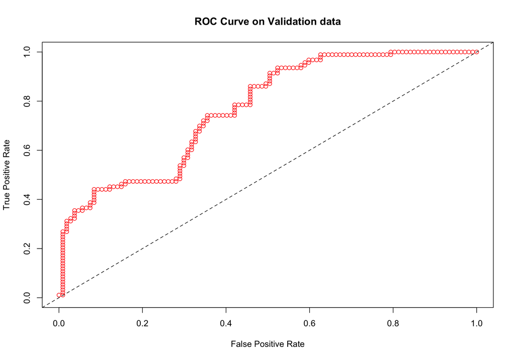

```r
plot(perf,col=2, main = "ROC Curve on Validation data")
```

```r
print(sprintf("Best Automl leader Validation AUC:  %s", h2o.auc(perf)))
```

```
## [1] "Best Automl leader Validation AUC:  0.767259571902321"
```

Here is the summary of the model with the best performance on validation dataset.

```r
automl_leader
```

```
## Model Details:
## ==============
##
## H2OBinomialModel: gbm
## Model ID:  GBM_grid_1_AutoML_20171117_133026_model_5
## Model Summary:
##   number_of_trees number_of_internal_trees model_size_in_bytes min_depth
## 1              81                       81               92976         8
##   max_depth mean_depth min_leaves max_leaves mean_leaves
## 1         8    8.00000         43        117    86.49383
##
##
## H2OBinomialMetrics: gbm
## ** Reported on training data. **
##
## MSE:  0.06388461
## RMSE:  0.2527541
## LogLoss:  0.2316048
## Mean Per-Class Error:  0.0002121341
## AUC:  0.9999891
## Gini:  0.9999781
##
## Confusion Matrix (vertical: actual; across: predicted) for F1-optimal threshold:
##          0    1    Error     Rate
## 0      194    0 0.000000   =0/194
## 1        1 2356 0.000424  =1/2357
## Totals 195 2356 0.000392  =1/2551
##
## Maximum Metrics: Maximum metrics at their respective thresholds
##                         metric threshold    value idx
## 1                       max f1  0.911114 0.999788 246
## 2                       max f2  0.911114 0.999661 246
## 3                 max f0point5  0.911114 0.999915 246
## 4                 max accuracy  0.911114 0.999608 246
## 5                max precision  0.929852 1.000000   0
## 6                   max recall  0.899513 1.000000 252
## 7              max specificity  0.929852 1.000000   0
## 8             max absolute_mcc  0.911114 0.997221 246
## 9   max min_per_class_accuracy  0.911114 0.999576 246
## 10 max mean_per_class_accuracy  0.911114 0.999788 246
```

[output cut: 89 more lines]

```
## f0point5                        1.0   0.99830437         1.0
## f1                              1.0    0.9989396         1.0
## f2                              1.0   0.99957556         1.0
## lift_top_group              1.08742    1.0828025   1.0782241
## logloss                  0.24654457   0.23831242  0.22884804
## max_per_class_error             0.0  0.025641026         0.0
## mcc                             1.0      0.98605         1.0
## mean_per_class_accuracy         1.0   0.98717946         1.0
## mean_per_class_error            0.0  0.012820513         0.0
## mse                     0.068493605   0.06535973  0.06203941
## precision                       1.0   0.99788135         1.0
## r2                       0.07352506   0.07452416 0.077969834
## recall                          1.0          1.0         1.0
## rmse                     0.26171282    0.2556555  0.24907711
## specificity                     1.0     0.974359         1.0
```

# 4 Conclusion

When working on datasets, it is important to check on the structure and content. Knowing your dataset can help build features that could boost performance. Imbalance train data can impact the performance of your model. It is always a good to have a linear model as a benchmark.

```r
# All done, shutdown H2O
h2o.shutdown(prompt=FALSE)
```